# SARS-CoV-2 Data Analysis

Ronnie Volman

Project Progress: Week of 7/17

# Key Achievements

- Added code for computing the summary metrics per clade
- Conducted preliminary analysis of data

```r
#Package loading
require(ggplot2)
require(dplyr)
#Loading information previously processed with Chronumental + file with clade information.
chronum_output = read.delim("~/projects/chronumental/chronumental_dates_public-2022-03-11.metadata.tsv.gz.tsv")
# input to chronumental
chronum_input = read.delim("~/projects/chronumental/public-2022-03-11.metadata.tsv.gz")
# clade information
clade_df = read.delim("~/projects/chronumental/newclade1")
```

Selected clade roots from chronum_output and matched with clade information.

```r
clade_info = merge(clade_df,
                   chronum_output %>% dplyr::filter(grepl("node", strain)),
                   by.x = "clade_root_node", by.y = "strain")
```

```r
# Compute summary metrics on data and match to clade info to obtain final dataframe
final_result = merge(chronum_input %>%
                   dplyr::group_by(pangolin_lineage) %>%
                   dplyr::summarize(min_date = min(date),
                                    max_date = max(date),
                                    nmins = sum(date == min(date)),
                                    nmembers = n()),
                 clade_info,
                 by.x = "pangolin_lineage", by.y = "clade")

# Filter out incomplete dates
final_result = final_result %>%
  dplyr::filter(nchar(min_date, type = "chars") == 10 &
                nchar(max_date, type = "chars") == 10)

# Compute days from predicted emergence to first sampling
final_result$days = with(final_result, difftime(min_date, predicted_date, units = "days"))

# Compute days from first sampling to last sampling
final_result$clade_spread = with(final_result, difftime(max_date, min_date, units = "days"))

# Join with chronum_input to add country info
final_result = dplyr::inner_join(final_result,
                                 chronum_input %>% dplyr::rename(min_date = date))
```

# Results

## Preliminary Country Analysis

To begin, it is interesting to view a distribution of the number of unique countries per clade. We can observe that generally, there is a larger quantity of clades with less than ~10 unique countries. This suggests that for many clades, sampling was confined to one country.

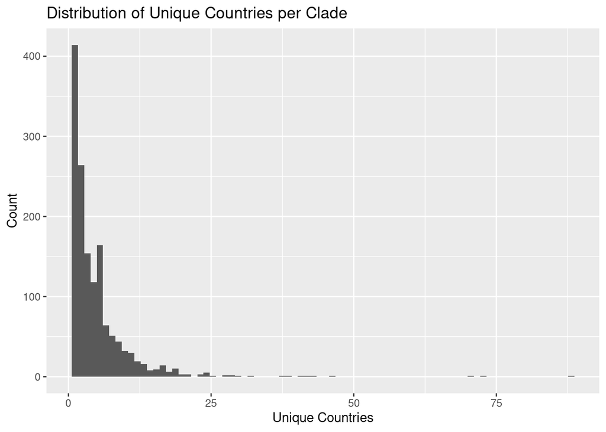

```r
# Compute number of unique countries per clade
unique_countries_per_clade = chronum_input %>% dplyr::group_by(pangolin_lineage) %>% dplyr::summarise(unique_countries = length(unique(country)))

# Plot
ggplot(unique_countries_per_clade,
       aes(x = unique_countries)) +
  geom_histogram(bins = 80) +
  labs(x = "Unique Countries",
       y = "Count",
       title = "Distribution of Unique Countries per Clade")
```